# Data Driven Student Support

Elisabeth Lackner and Patrick Wynne

November 20, 2017

## Question

- Can timely data monitoring increase student success for first-time full-time freshmen?

## Objective

- In a campus wide effort, Institutional Research, IT, Student Affairs, Institutional Effectiveness, and Registrar met regularly throughout the summer and fall of 2016 to discuss interventions for the Fall 2016 first-time full-time cohort
- The objective was to establish a daily updated dashboard with student data that would allow targeted outreach to students

## Data Needs

- The team decided to focus energy on the following areas
1. Early Alert
2. College Readiness
3. Academic Engagement
4. Student Information

## Early Alert

[figure not shown]

## College Readiness

- High school GPA
- Remedial needs - math, reading, and/or writing

## Student Demographics

- Name
- Gender
- Ethnicity
- Student ID

## Student Demographics Continued

- Major and Academy
- ASAP status
- Enrolled in writing intensive
- Enrolled in ST100
- Course withdrawals
- Withdrawal from the college

## Student Financials

- Financial aid
- Outstanding balances

## Dashboard

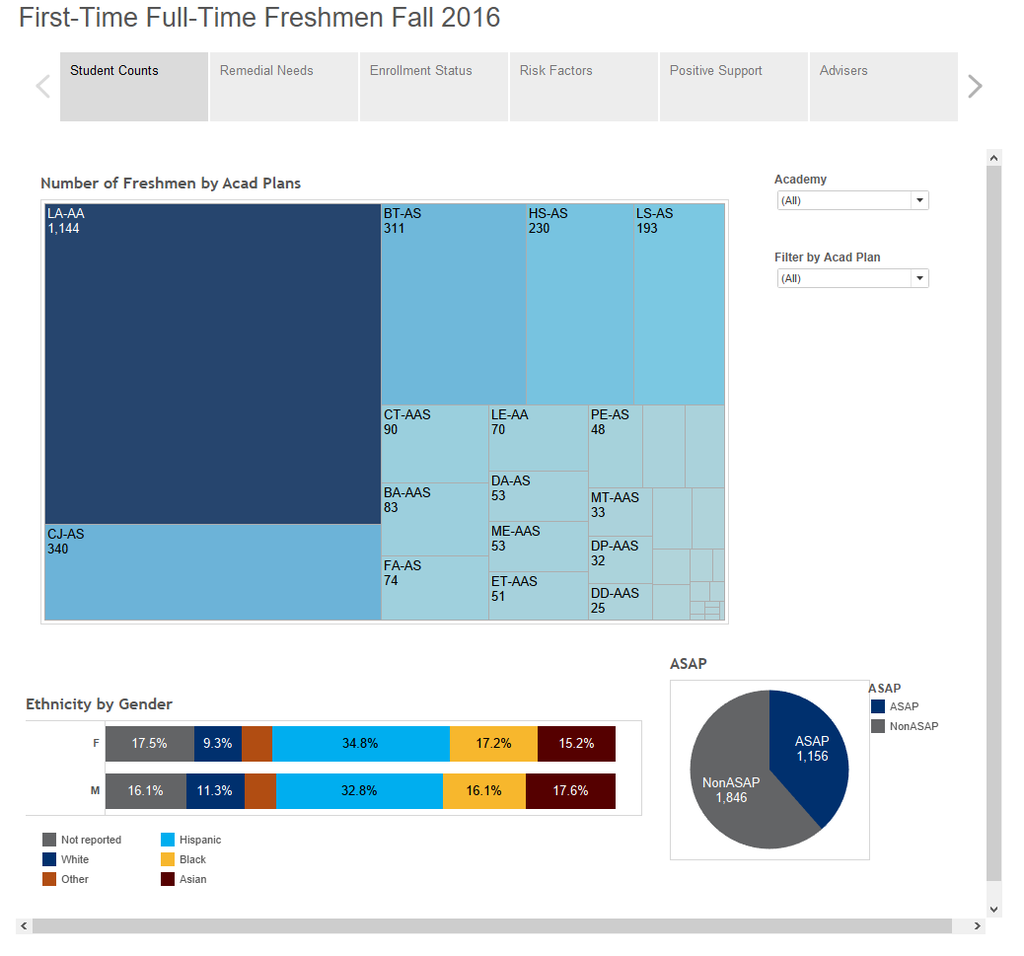

## Dashboard

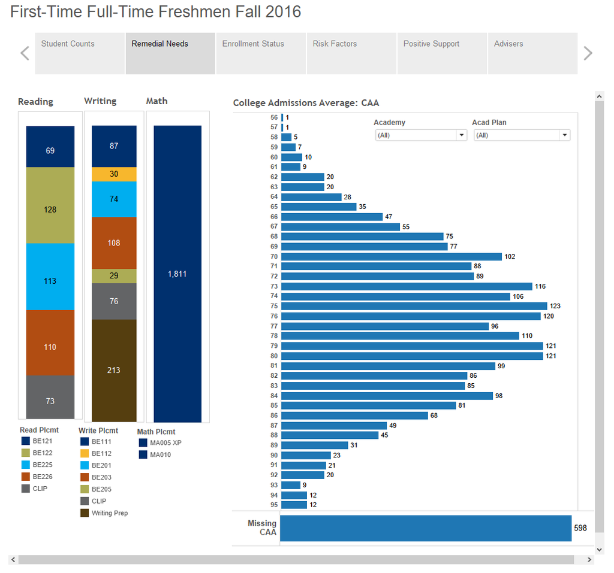

## Dashboard

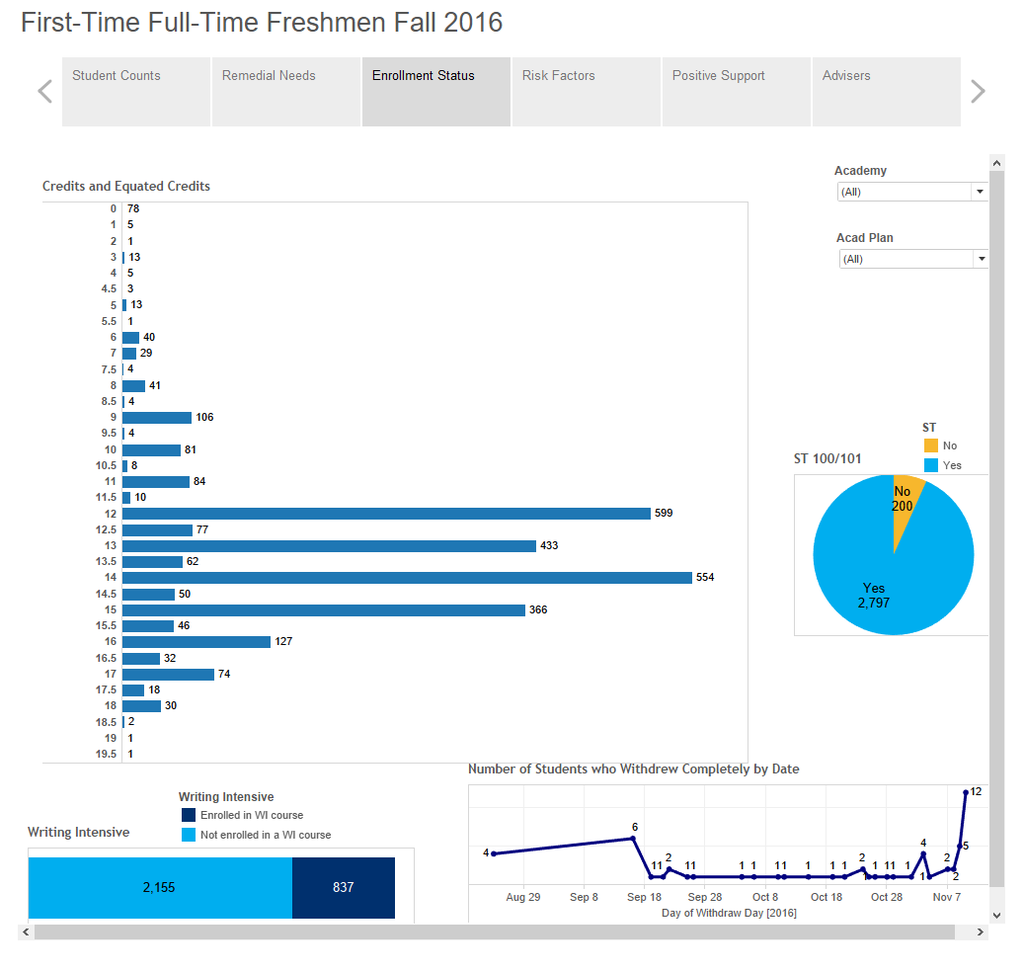

## Dashboard

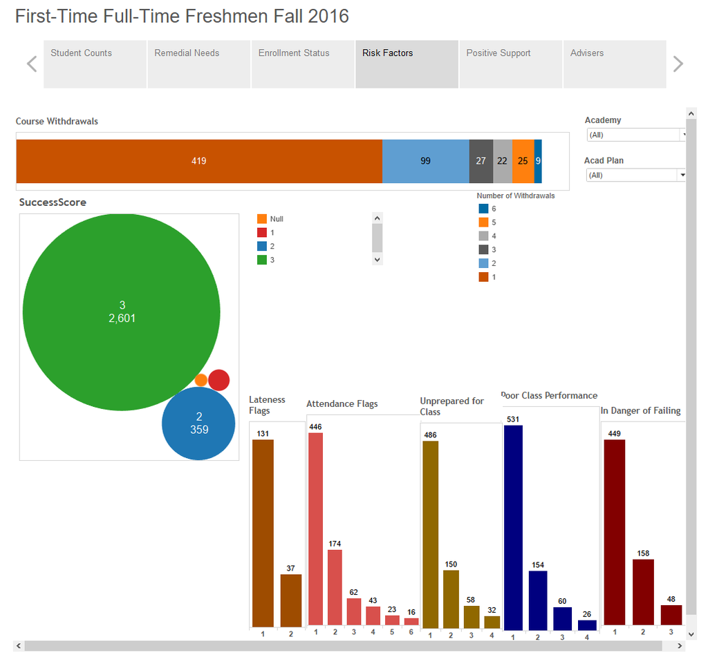

## Dashboard

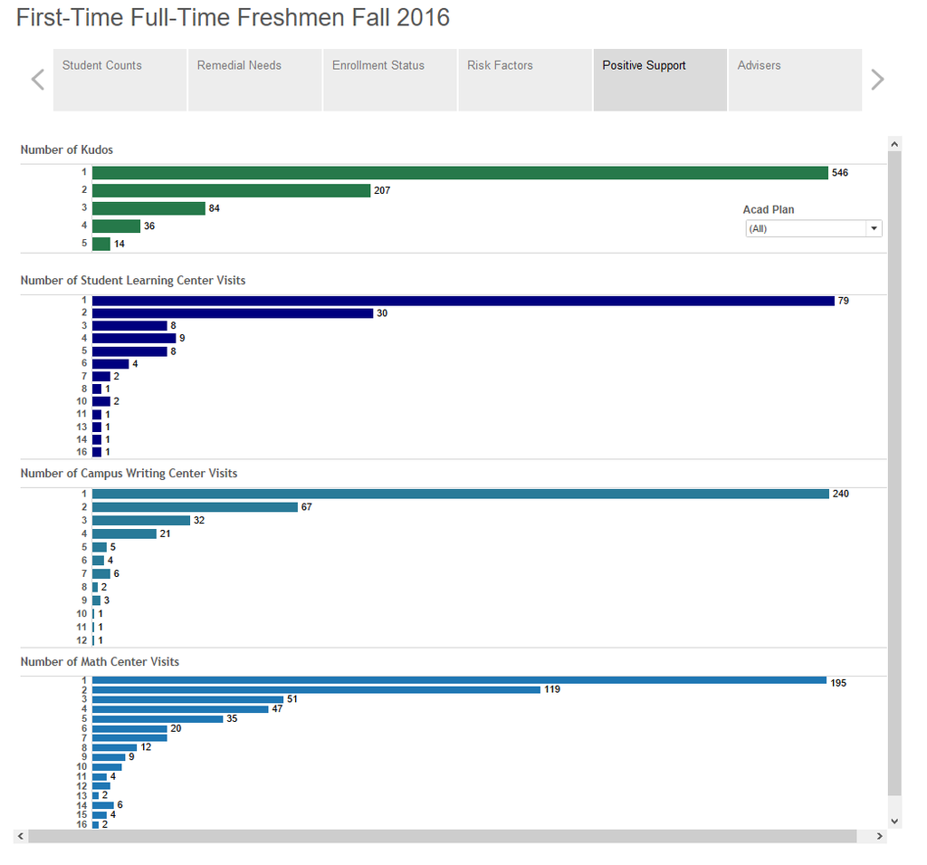

## Dashboard

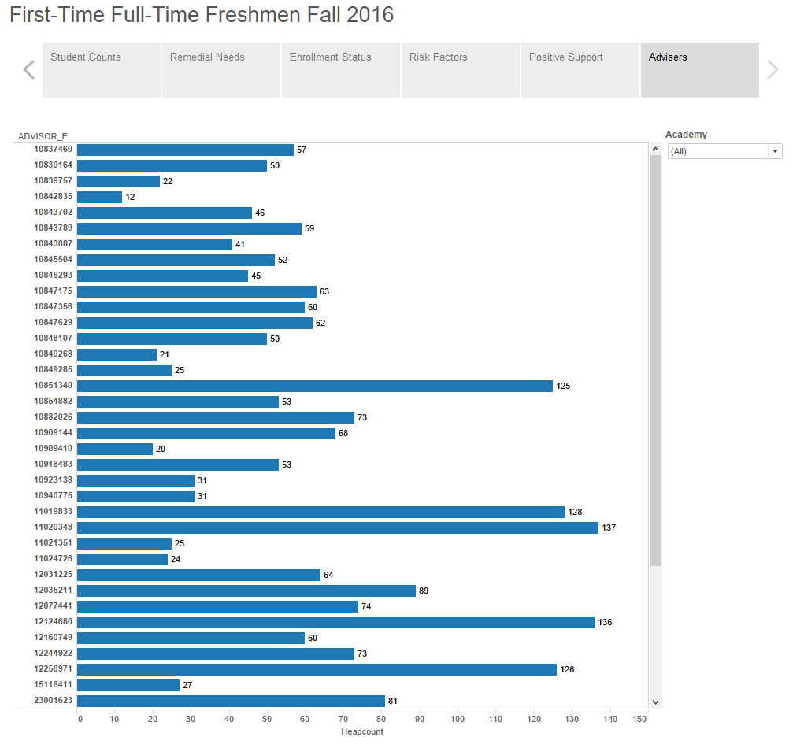

## Actions taken

- Advisors receive lists of students with contact information who displayed risky behavior
1. Required to take remedial math but didn’t enroll
2. Were not enrolled in ST 100
3. Had a success score of 1 or 2 (based on internal rentention prediction model)